# SBRT Survival Analysis

Jessica Scarborough

3/21/2022

# Data Management

## Ingest cleaned, deidentified data

These are the data sent to Jessica from Dr. Jacob Scott. They were previously de-identified and the only change made was conversion from `.xlsx` to `.csv` file type.

```r
data_tidy <- read.csv(here("data", "pt_data_deidentified.csv")) %>%
  mutate(pred_var = `CT..Cm.`, # to work with universal sweep functions below
         tumor_size = `CT..Cm.`) # for readability in coxph analysis
```

# Data Analysis

We’ll start by creating our `Surv` objects. We’ll need one for overall survival (OS), one for local control (LC), and one for chemo free survival.

```r
surv_os <- Surv(time = data_tidy$OS.Time,
                event = data_tidy$OS.Index)

surv_lc <- Surv(time = data_tidy$Local.Failure.Time,
                event = data_tidy$Local.Failure.Index)

surv_chemo <- Surv(time = data_tidy$Chemo.Time,
                event = data_tidy$Chemo.Index)
```

## Cox PH model

### OS

First we’ll predict OS using tumor size as univariate predictor. Then, we’ll use tumor size, age at diagnosis, KP and histology as predictors.

```r
coxph(surv_os ~ tumor_size, data = data_tidy)
```

```
## Call:
## coxph(formula = surv_os ~ tumor_size, data = data_tidy)
##
##              coef exp(coef) se(coef)     z      p
## tumor_size 0.2573    1.2935   0.1264 2.036 0.0417
##
## Likelihood ratio test=3.74  on 1 df, p=0.0532
## n= 50, number of events= 27
```

```r
coxph(surv_os ~ tumor_size + `Age.at.Diagnosis` + `KPS` + `NEW.HISTOLOGY`, data = data_tidy)
```

```
## Call:
## coxph(formula = surv_os ~ tumor_size + Age.at.Diagnosis + KPS +
##     NEW.HISTOLOGY, data = data_tidy)
##
##                       coef exp(coef)  se(coef)      z      p
## tumor_size        0.308813  1.361808  0.152142  2.030 0.0424
## Age.at.Diagnosis -0.006401  0.993619  0.017661 -0.362 0.7170
## KPS              -0.023504  0.976770  0.021748 -1.081 0.2798
## NEW.HISTOLOGYSTS -0.411862  0.662415  0.508748 -0.810 0.4182
##
## Likelihood ratio test=4.62  on 4 df, p=0.3281
## n= 48, number of events= 27
##    (2 observations deleted due to missingness)
```

### LC

Next, we’ll predict LS using tumor size as univariate predictor. Then, we’ll use tumor size, age at diagnosis, KP and histology as predictors.

```r
coxph(surv_lc ~ tumor_size, data = data_tidy)
```

```
## Call:
## coxph(formula = surv_lc ~ tumor_size, data = data_tidy)
##
##              coef exp(coef) se(coef)    z      p
## tumor_size 0.5061    1.6589   0.2707 1.87 0.0615
##
## Likelihood ratio test=3.09  on 1 df, p=0.07892
## n= 50, number of events= 4
```

```r
coxph(surv_lc ~ tumor_size + `Age.at.Diagnosis` + `KPS` + `NEW.HISTOLOGY`, data = data_tidy)
```

```
## Call:
## coxph(formula = surv_lc ~ tumor_size + Age.at.Diagnosis + KPS +
##     NEW.HISTOLOGY, data = data_tidy)
##
##                       coef exp(coef)  se(coef)      z      p
## tumor_size        1.206902  3.343111  0.707058  1.707 0.0878
## Age.at.Diagnosis  0.002775  1.002778  0.071568  0.039 0.9691
## KPS              -0.004402  0.995608  0.075670 -0.058 0.9536
## NEW.HISTOLOGYSTS -3.064246  0.046689  2.952788 -1.038 0.2994
##
## Likelihood ratio test=7.1  on 4 df, p=0.1305
## n= 48, number of events= 3
##    (2 observations deleted due to missingness)
```

## KM Analysis

We want to find the optimal single cutpoint for tumor size and the optimal two cutpoints for tumor size. To do this we will sweep through all possible single (`sweep_cutpoints1`) and double cutpoints (`sweep_cutpoints2`) and select the optimal ones based on discrimination in survival outcomes. We will store our single optimal cutpoint as `single_cutpoint_best` and double optimal cutpoint as `double_cutpoint_best`.

### Cutpoint Functions

```r
sweep_cutpoints1 <- function(tidy_data, surv_obj){
   cutpoints = quantile(tidy_data$pred_var, prob = seq(0, 1, 0.01))[-(1:5)]
   cutpoints = cutpoints[-(96:101)]
   cutpoint_vec <- c()
   chisq_vec <- c()
   low_n_vec <- c()
   high_n_vec <- c()
   for (i in 1:length(cutpoints)){
      tidy_data_labs <- tidy_data %>%
         mutate(pred_group = ifelse(pred_var <= cutpoints[i], "low", "high"))
      survdiff_results <- survdiff(surv_obj ~ pred_group, data = tidy_data_labs)
      chisq_vec <- c(chisq_vec, survdiff_results$chisq)
      cutpoint_vec <- c(cutpoint_vec, cutpoints[i])
      low_n_vec <- c(low_n_vec, nrow(tidy_data_labs %>% filter(pred_group == "low")))
      high_n_vec <- c(high_n_vec, nrow(tidy_data_labs %>% filter(pred_group == "high")))
   }
   data.frame(cutpoint = cutpoint_vec,
              low_n = low_n_vec,
              high_n = high_n_vec,
              chisq = chisq_vec) %>%
      rowwise() %>%
      mutate(min_n = min(low_n, high_n)) %>%
      ungroup()
}


sweep_cutpoints2 <- function(tidy_data, surv_obj){
   cutpoints_first = quantile(tidy_data$pred_var, prob = seq(0, 1, 0.01))[-(1:5)]
   cutpoints_first = cutpoints_first[-(96:101)]
   cutpoint_first_vec <- c()
   cutpoint_second_vec <- c()
   low_n_vec <- c()
   middle_n_vec <- c()
   high_n_vec <- c()
   chisq_vec <- c()
   for (i in 1:length(cutpoints_first)){
      pred_var_after_cutoff <- tidy_data$pred_var[tidy_data$pred_var > min(cutpoints_first[])]
      cutpoints_second <- quantile(pred_var_after_cutoff, prob = seq(0, 1, 0.01))[-(1:5)]
      cutpoints_second <- cutpoints_second[-(96:101)]
      for (j in 1:length(cutpoints_second)){
         tidy_data_labs <- tidy_data %>%
            mutate(pred_group = case_when(pred_var <= cutpoints_first[i] ~ "low",
                                          pred_var > cutpoints_first[i] &
                                             pred_var <= cutpoints_second[j] ~ "middle",
                                          pred_var > cutpoints_second[j] ~ "high"))
         survdiff_results <- survdiff(surv_obj ~ pred_group, data = tidy_data_labs)
         chisq_vec <- c(chisq_vec, survdiff_results$chisq)
         cutpoint_first_vec <- c(cutpoint_first_vec, cutpoints_first[[i]])
         cutpoint_second_vec <- c(cutpoint_second_vec, cutpoints_second[[j]])
         low_n_vec <- c(low_n_vec, nrow(tidy_data_labs %>% filter(pred_group == "low")))
         middle_n_vec <- c(middle_n_vec, nrow(tidy_data_labs %>% filter(pred_group == "middle")))
         high_n_vec <- c(high_n_vec, nrow(tidy_data_labs %>% filter(pred_group == "high")))
      }
   }
   data.frame(cutpoint1 = cutpoint_first_vec,
              cutpoint2 = cutpoint_second_vec,
              low_n = low_n_vec,
              middle_n = middle_n_vec,
              high_n = high_n_vec,
              chisq = chisq_vec) %>%
      rowwise() %>%
      mutate(min_n = min(low_n, middle_n, high_n)) %>%
      ungroup()
}

sweep_cutpoints2 <- function(tidy_data, surv_obj){
   cutpoints_first = quantile(tidy_data$pred_var, prob = seq(0, 1, 0.01))[-(1:5)]
   cutpoints_first = cutpoints_first[-(96:101)]
   cutpoint_first_vec <- c()
   cutpoint_second_vec <- c()
   low_n_vec <- c()
   middle_n_vec <- c()
   high_n_vec <- c()
   chisq_vec <- c()
   for (i in 1:length(cutpoints_first)){
      pred_var_after_cutoff <- tidy_data$pred_var[tidy_data$pred_var > cutpoints_first[i]]
      cutpoints_second <- quantile(pred_var_after_cutoff, prob = seq(0, 1, 0.01))[-(1:5)]
      cutpoints_second <- cutpoints_second[-(96:101)]
      for (j in 1:length(cutpoints_second)){
         tidy_data_labs <- tidy_data %>%
            mutate(pred_group = case_when(pred_var <= cutpoints_first[i] ~ "low",
                                          pred_var > cutpoints_first[i] &
                                             pred_var <= cutpoints_second[j] ~ "middle",
                                          pred_var > cutpoints_second[j] ~ "high"))
         survdiff_results <- survdiff(surv_obj ~ pred_group, data = tidy_data_labs)
         chisq_vec <- c(chisq_vec, survdiff_results$chisq)
         cutpoint_first_vec <- c(cutpoint_first_vec, cutpoints_first[[i]])
         cutpoint_second_vec <- c(cutpoint_second_vec, cutpoints_second[[j]])
         low_n_vec <- c(low_n_vec, nrow(tidy_data_labs %>% filter(pred_group == "low")))
         middle_n_vec <- c(middle_n_vec, nrow(tidy_data_labs %>% filter(pred_group == "middle")))
         high_n_vec <- c(high_n_vec, nrow(tidy_data_labs %>% filter(pred_group == "high")))
      }
   }
   data.frame(cutpoint1 = cutpoint_first_vec,
              cutpoint2 = cutpoint_second_vec,
              low_n = low_n_vec,
              middle_n = middle_n_vec,
              high_n = high_n_vec,
              chisq = chisq_vec) %>%
      rowwise() %>%
      mutate(min_n = min(low_n, middle_n, high_n)) %>%
      ungroup()
}
```

### OS

#### Find cutoffs

```r
# single cutpoint

cutpoints_1_os <- sweep_cutpoints1(data_tidy, surv_os)
saveRDS(cutpoints_1_os, here("results", "all_cutpoints1_os.rds"))

cutpoints_1_n5_os <- cutpoints_1_os %>%
   filter(min_n >= 5) %>% #require at least 4 samples in each group
   filter(chisq == max(chisq)) # cutpoints with the highest chisq result


# they all cut the data with the same samples in each group
# taking the median to get a single value
single_cutpoint_best_os <- median(cutpoints_1_n5_os$cutpoint)


# double cutpoint

cutpoints_2_os <- sweep_cutpoints2(data_tidy, surv_os)
saveRDS(cutpoints_2_os, here("results", "all_cutpoints2_os.rds"))
cutpoints_2_os <- readRDS(here("results", "all_cutpoints2_os.rds"))

cutpoints_2_n5_os <- cutpoints_2_os %>%
   filter(min_n >= 5) %>% #require at least 4 samples in each group
   filter(chisq == max(chisq)) # cutpoints with the highest chisq result


# they all cut the data with the same samples in each group
# taking the first option for simplicity
double_cutpoint_best_os <- c(cut1 = cutpoints_2_n5_os[1, ]$cutpoint1,
                          cut2 = cutpoints_2_n5_os[1, ]$cutpoint2)
```

##### Classify patients into cohorts

Now, based on our optimal cutpoints, we will classify patients by their optimal cutpoints.

```r
# classify predictions
data_class_os <- data_tidy %>%
      mutate(pred_grp2_med = factor(case_when(pred_var < median(pred_var) ~ "1_Small_Size",
                                              pred_var >= median(pred_var) ~ "2_High_Size"),
                             ordered = TRUE),
          pred_grp2_optimal = case_when(pred_var < single_cutpoint_best_os ~ "1_Small_Size",
                                        pred_var >= single_cutpoint_best_os ~ "2_High_Size"),
          pred_grp3_tert = factor(case_when(pred_var < quantile(pred_var, 0.33) ~ "1_Small_Size",
                                pred_var >= quantile(pred_var, 0.33) &
                                   pred_var < quantile(pred_var, 0.66) ~ "2_Medium_Size",
                                pred_var >= quantile(pred_var, 0.66) ~ "3_Large_Size"),
                                ordered = TRUE),
          pred_grp3_optimal = case_when(pred_var <= double_cutpoint_best_os["cut1"] ~ "1_Small_Size",
                                pred_var > double_cutpoint_best_os["cut1"] &
                                   pred_var <= double_cutpoint_best_os["cut2"] ~ "2_Medium_Size",
                                pred_var > double_cutpoint_best_os["cut2"] ~ "3_Large_Size"),
          pred_grp3_man = factor(case_when(pred_var < 2 ~ "1_Small_Size",
                                pred_var >= 2 &
                                   pred_var < 4 ~ "2_Medium_Size",
                                pred_var >= 4 ~ "3_Large_Size"),
                                ordered = TRUE))
```

#### Plot KM Curves

Now, we have a variety of cohorts to separate each group by. We will plot the KM curves for each.

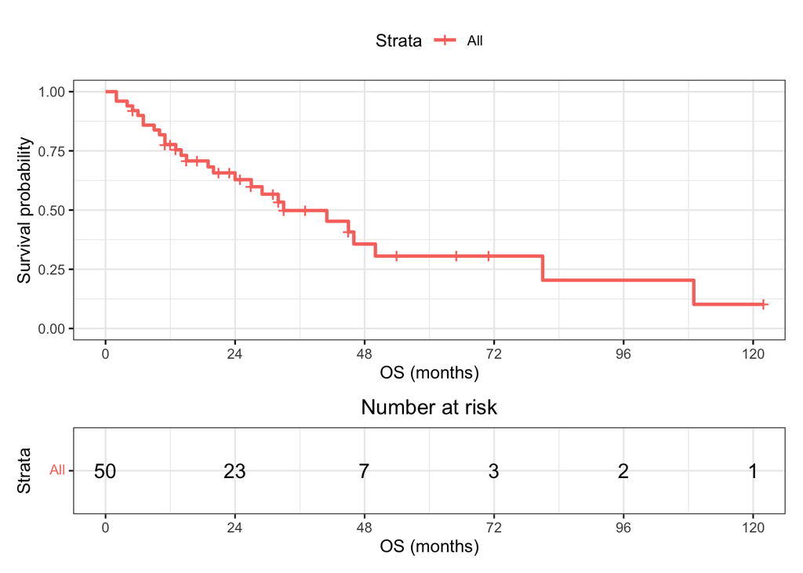

```r
## ## ## ## ## ## ## ## ## ## ## ## ## ## ## ## ## ## ## ## ## ## ## ## ##

## Intercept only

km_int <- survfit(surv_os ~ 1)

gg_int <- ggsurvplot(km_int, data = data_class_os,
   conf.int = FALSE, # Add confidence interval
   risk.table = TRUE, # Add risk table
   xlab = "OS (months)", # adjust X axis label
   # xlim = c(0, 190),
   break.time.by = 24, # add tick every 12 months
   # title = "OS - Intercept only",
   ggtheme = theme_bw() + theme(plot.title = element_text(hjust = 0.5))
   )

combo_os_int <- gg_int$plot + gg_int$table +
   plot_layout(nrow = 2, ncol = 1, heights = c(3, 1))

combo_os_int
```

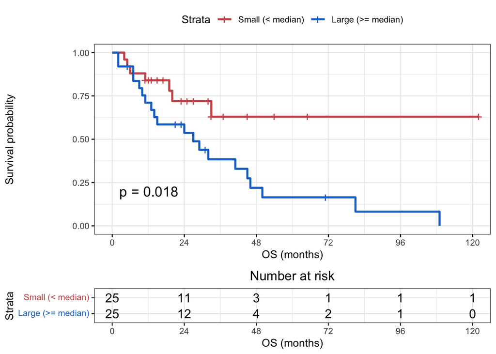

```r
ggsave(filename = here("results", "surv_os_int_only.png"),
       plot = combo_os_int, height = 5, width = 5)

## ## ## ## ## ## ## ## ## ## ## ## ## ## ## ## ## ## ## ## ## ## ## ## ##

## Top/bottom halves

km_grp2_med <- survfit(surv_os ~ data_class_os$pred_grp2_med)

gg_grp2_med <- ggsurvplot(km_grp2_med, data = data_class_os, size = 1,
   palette = c("indianred3", "dodgerblue3"), # custom colors
   conf.int = FALSE, # Add confidence interval
   pval = TRUE, # Add p-value
   risk.table = TRUE, # Add risk table
   risk.table.height = 0.250, # change if you have >2 groups
   risk.table.y.text.col = T, # show colors in table listing
   ncensor.plot = FALSE,
   ncensor.plot.height = 0.25,
   xlab = "OS (months)", # adjust X axis label
   # xlim = c(0, 190),
   break.time.by = 24, # break X axis in time intervals
   # legend.labs = c("High Linear Pred.", "Low Linear Pred."),
   # labels are opposite of "Cissig score, where higher equals better outcomes
   # title = "CisSig Score Cohorts - Yes Cisplatin",
   legend.labs = c("Small (< median)", "Large (>= median)"),
   # title = "OS - Preset Cutoff (Median)",
   ggtheme = theme_bw() + theme(plot.title = element_text(hjust = 0.5))
   )

gg_grp2_med
```

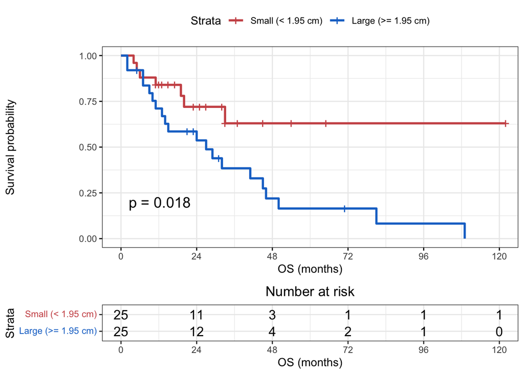

```r
## ## ## ## ## ## ## ## ## ## ## ## ## ## ## ## ## ## ## ## ## ## ## ## ##

## Optimal 2 group cutpoints

km_grp2_opt <- survfit(surv_os ~ data_class_os$pred_grp2_optimal)

gg_grp2_opt <- ggsurvplot(km_grp2_opt, data = data_class_os, size = 1,
   palette = c("indianred3", "dodgerblue3"), # custom colors
   conf.int = FALSE, # Add confidence interval
   pval = TRUE, # Add p-value
   risk.table = TRUE, # Add risk table
   risk.table.height = 0.25, # change if you have >2 groups
   risk.table.y.text.col = T, # show colors in table listing
   ncensor.plot = FALSE,
   ncensor.plot.height = 0.25,
   xlab = "OS (months)", # adjust X axis label
   # xlim = c(0, 190),
   break.time.by = 24, # break X axis in time intervals
   # legend.labs = c("Lowest third Lin Pred.", "Middle third Lin Pred.",
   # "Top third Lin Pred."), # labels
   # title = "CisSig Score 2 Cohorts (optimal) - Yes Cisplatin",
   legend.labs = c("Small (< 1.95 cm)", "Large (>= 1.95 cm)"),
   # title = "OS - Optimal Cutoff",
   ggtheme = theme_bw() + theme(plot.title = element_text(hjust = 0.5))
   )

gg_grp2_opt
```

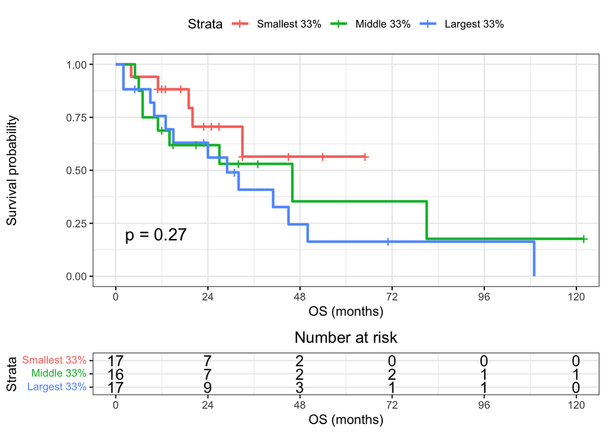

```r
## ## ## ## ## ## ## ## ## ## ## ## ## ## ## ## ## ## ## ## ## ## ## ## ##

## Three groups by tertiles by 33%

km_grp3_tert3 <- survfit(surv_os ~ data_class_os$pred_grp3_tert)

gg_grp3_tert <- ggsurvplot(km_grp3_tert3, data = data_class_os, size = 1,
   conf.int = FALSE, # Add confidence interval
   pval = TRUE, # Add p-value
   risk.table = TRUE, # Add risk table
   risk.table.height = 0.25, # change if you have >2 groups
   risk.table.y.text.col = T, # show colors in table listing
   ncensor.plot = FALSE,
   ncensor.plot.height = 0.25,
   xlab = "OS (months)", # adjust X axis label
   # xlim = c(0, 190),
   break.time.by = 24, # break X axis in time intervals
   # legend.labs = c("Lowest third Lin Pred.", "Middle third Lin Pred.",
   # "Top third Lin Pred."), # labels
   # title = "CisSig Score Tertile Cohorts (by 33%) - Yes Cisplatin",
   legend.labs = c("Smallest 33%", "Middle 33%", "Largest 33%"),
   # title = "OS - Preset Cutoffs (Tertiles)",
   ggtheme = theme_bw() + theme(plot.title = element_text(hjust = 0.5))
   )

gg_grp3_tert
```

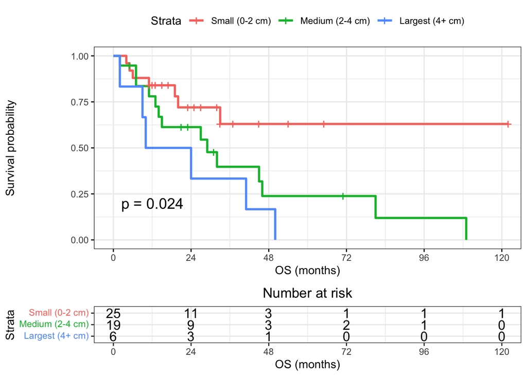

```r
## ## ## ## ## ## ## ## ## ## ## ## ## ## ## ## ## ## ## ## ## ## ## ## ##

## Three groups by manual cutoffs (0-2, 2-4, >4)

km_grp3_manual <- survfit(surv_os ~ data_class_os$pred_grp3_man)

gg_grp3_manual <- ggsurvplot(km_grp3_manual, data = data_class_os, size = 1,
   conf.int = FALSE, # Add confidence interval
   pval = TRUE, # Add p-value
   risk.table = TRUE, # Add risk table
   risk.table.height = 0.25, # change if you have >2 groups
   risk.table.y.text.col = T, # show colors in table listing
   ncensor.plot = FALSE,
   ncensor.plot.height = 0.25,
   xlab = "OS (months)", # adjust X axis label
   # xlim = c(0, 190),
   break.time.by = 24, # break X axis in time intervals
   # # legend.labs = c("Bottom 25% Lin Pred.", "Middle 25-75% Lin Pred.",
   # "Top 25% Lin Pred."), # labels
   # title = "CisSig Score Tertile Cohorts (by 25/50/25%) - Yes Cisplatin",
   legend.labs = c("Small (0-2 cm)", "Medium (2-4 cm)", "Largest (4+ cm)"),
   # title = "OS - Preset Cutoffs (0-2, 2-4, 4+)",
   ggtheme = theme_bw() + theme(plot.title = element_text(hjust = 0.5))
   )

gg_grp3_manual
```

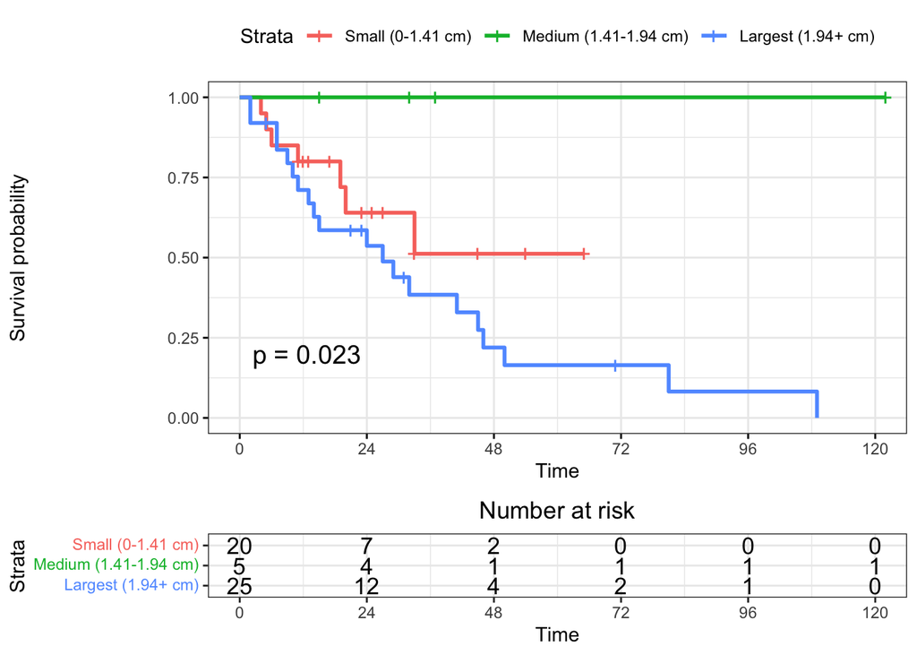

```r
## ## ## ## ## ## ## ## ## ## ## ## ## ## ## ## ## ## ## ## ## ## ## ## ##

## Optimal 3 group cutpoints

km_grp3_opt <- survfit(surv_os ~ data_class_os$pred_grp3_optimal)

gg_grp3_opt <- ggsurvplot(km_grp3_opt, data = data_class_os, size = 1,
   conf.int = FALSE, # Add confidence interval
   pval = TRUE, # Add p-value
   risk.table = TRUE, # Add risk table
   risk.table.height = 0.25, # change if you have >2 groups
   risk.table.y.text.col = T, # show colors in table listing
   ncensor.plot = FALSE,
   ncensor.plot.height = 0.25,
   # xlab = "OS (months)", # adjust X axis label
   # xlim = c(0, 190),
   break.time.by = 24, # break X axis in time intervals
   # legend.labs = c("Lowest third Lin Pred.", "Middle third Lin Pred.",
   # "Top third Lin Pred."), # labels
   # title = "CisSig Score Tertile Cohorts (optimal) - Yes Cisplatin",
   legend.labs = c("Small (0-1.41 cm)", "Medium (1.41-1.94 cm)", "Largest (1.94+ cm)"),
   # title = "OS - Optimal Cutoffs",
   ggtheme = theme_bw() + theme(plot.title = element_text(hjust = 0.5))
   )

gg_grp3_opt
```

```r
## ## ## ## ## ## ## ## ## ## ## ## ## ## ## ## ## ## ## ## ## ## ## ## ##
```

#### Plot together

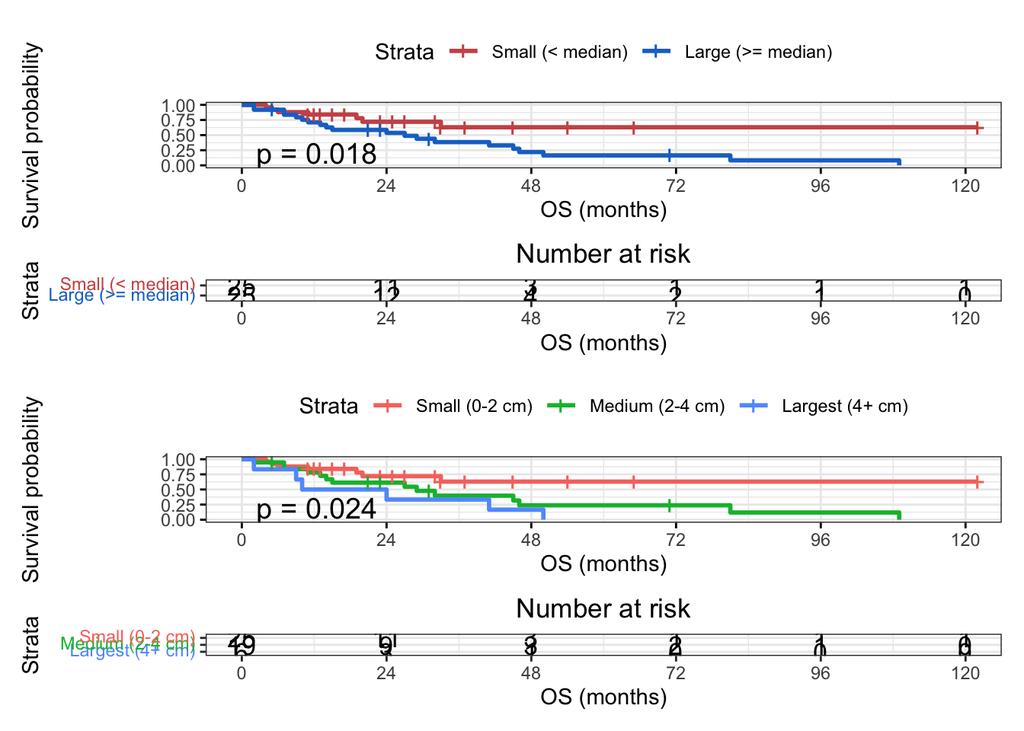

```r
combo_plot_preset <- gg_grp2_med$plot + gg_grp2_med$table +
   gg_grp3_manual$plot + gg_grp3_manual$table +
   plot_layout(nrow = 4, ncol = 1, heights = c(3, 1))

combo_plot_preset
```

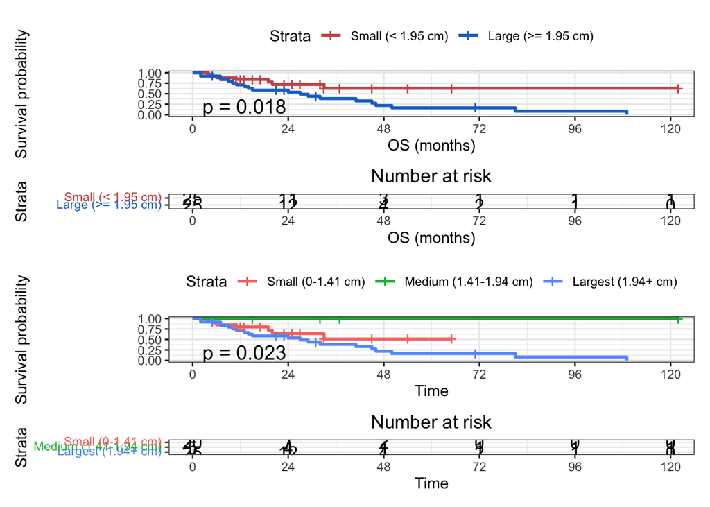

```r
ggsave(filename = here("results", "surv_os_plots_preset.png"),
       plot = combo_plot_preset, height = 10, width = 7)




combo_plot_opt <- gg_grp2_opt$plot + gg_grp2_opt$table +
   gg_grp3_opt$plot + gg_grp3_opt$table +
   plot_layout(nrow = 4, ncol = 1, heights = c(3, 1))

combo_plot_opt
```

```r
ggsave(filename = here("results", "surv_os_plots_opt.png"),
       plot = combo_plot_opt, height = 10, width = 7)
```

### LC

#### Find cutoffs

```r
cutpoints_1_lc <- sweep_cutpoints1(data_tidy, surv_lc)
saveRDS(cutpoints_1_lc, here("results", "all_cutpoints1_lc.rds"))

cutpoints_1_n5_lc <- cutpoints_1_lc %>%
   filter(min_n >= 5) %>% #require at least 4 samples in each group
   filter(chisq == max(chisq)) # cutpoints with the highest chisq result

# they all cut the data with the same samples in each group
# taking the median to get a single value
single_cutpoint_best_lc <- median(cutpoints_1_n5_lc$cutpoint)

cutpoints_2_lc <- sweep_cutpoints2(data_tidy, surv_lc)
saveRDS(cutpoints_2_lc, here("results", "all_cutpoints2_lc.rds"))
cutpoints_2_lc <- readRDS(here("results", "all_cutpoints2_lc.rds"))

cutpoints_2_n5_lc <- cutpoints_2_lc %>%
   filter(min_n >= 5) %>% #require at least 4 samples in each group
   filter(chisq == max(chisq)) # cutpoints with the highest chisq result


# they all cut the data with the same samples in each group
# taking the first option for simplicity
double_cutpoint_best_lc <- c(cut1 = cutpoints_2_n5_lc[1, ]$cutpoint1,
                          cut2 = cutpoints_2_n5_lc[1, ]$cutpoint2)
```

#### Classify patients into cohorts

Now, based on our optimal cutpoints, we will classify patients by their optimal cutpoints.

```r
# classify predictions
data_class_lc <- data_tidy %>%
      mutate(pred_grp2_med = factor(case_when(pred_var < median(pred_var) ~ "1_Small_Size",
                                              pred_var >= median(pred_var) ~ "2_High_Size"),
                             ordered = TRUE),
          pred_grp2_optimal = case_when(pred_var < single_cutpoint_best_lc ~ "1_Small_Size",
                                        pred_var >= single_cutpoint_best_lc ~ "2_High_Size"),
          pred_grp3_tert = factor(case_when(pred_var < quantile(pred_var, 0.33) ~ "1_Small_Size",
                                pred_var >= quantile(pred_var, 0.33) &
                                   pred_var < quantile(pred_var, 0.66) ~ "2_Medium_Size",
                                pred_var >= quantile(pred_var, 0.66) ~ "3_Large_Size"),
                                ordered = TRUE),
          pred_grp3_optimal = case_when(pred_var <= double_cutpoint_best_lc["cut1"] ~ "1_Small_Size",
                                pred_var > double_cutpoint_best_lc["cut1"] &
                                   pred_var <= double_cutpoint_best_lc["cut2"] ~ "2_Medium_Size",
                                pred_var > double_cutpoint_best_lc["cut2"] ~ "3_Large_Size"),
          pred_grp3_man = factor(case_when(pred_var < 2 ~ "1_Small_Size",
                                pred_var >= 2 &
                                   pred_var < 4 ~ "2_Medium_Size",
                                pred_var >= 4 ~ "3_Large_Size"),
                                ordered = TRUE))
```

#### Plot KM Curves

Now, we have a variety of cohorts to separate each group by. We will plot the KM curves for each.

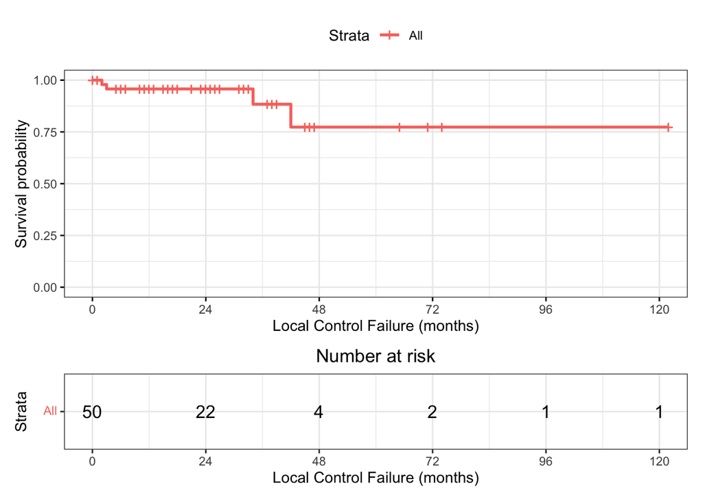

```r
## ## ## ## ## ## ## ## ## ## ## ## ## ## ## ## ## ## ## ## ## ## ## ## ##

## Intercept only

km_int <- survfit(surv_lc ~ 1)

gg_int <- ggsurvplot(km_int, data = data_class_lc,
   conf.int = FALSE, # Add confidence interval
   risk.table = TRUE, # Add risk table
   xlab = "Local Control Failure (months)", # adjust X axis label
   # xlim = c(0, 190),
   break.time.by = 24, # add tick every 12 months
   # title = "LC - Intercept only",
   ggtheme = theme_bw() + theme(plot.title = element_text(hjust = 0.5))
   )

combo_lc_int <- gg_int$plot + gg_int$table +
   plot_layout(nrow = 2, ncol = 1, heights = c(3, 1))

combo_lc_int
```

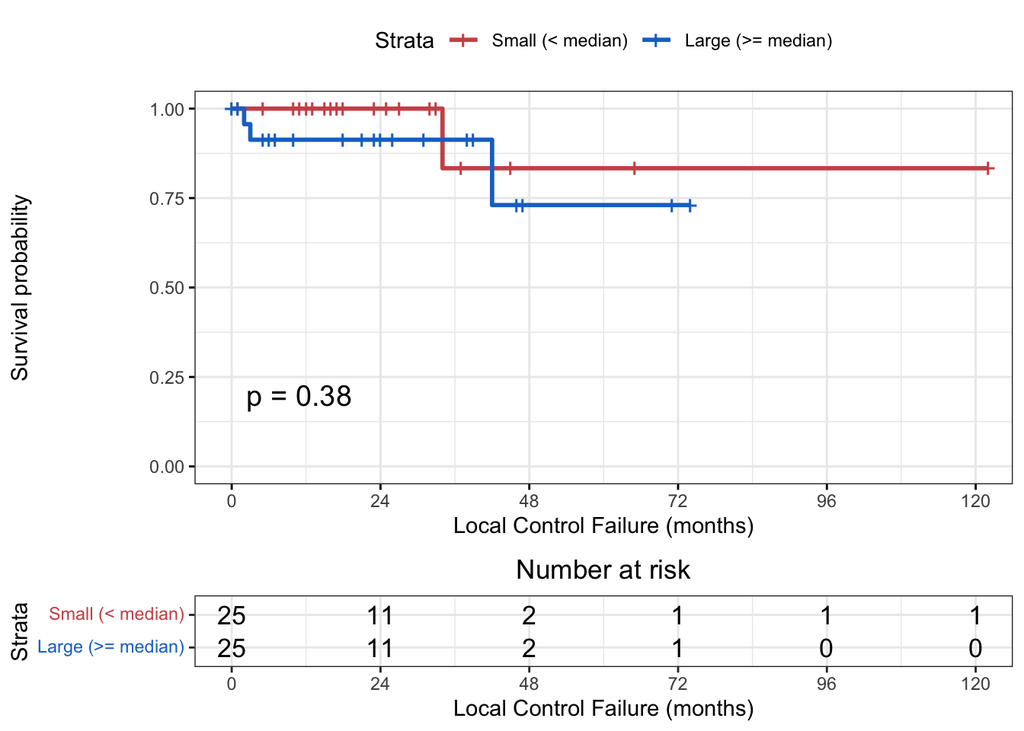

```r
ggsave(filename = here("results", "surv_lc_int_only.png"),
       plot = combo_lc_int, height = 5, width = 5)

## ## ## ## ## ## ## ## ## ## ## ## ## ## ## ## ## ## ## ## ## ## ## ## ##

## Top/bottom halves

km_grp2_med <- survfit(surv_lc ~ data_class_lc$pred_grp2_med)

gg_grp2_med <- ggsurvplot(km_grp2_med, data = data_class_lc, size = 1,
   palette = c("indianred3", "dodgerblue3"), # custom colors
   conf.int = FALSE, # Add confidence interval
   pval = TRUE, # Add p-value
   risk.table = TRUE, # Add risk table
   risk.table.height = 0.250, # change if you have >2 groups
   risk.table.y.text.col = T, # show colors in table listing
   ncensor.plot = FALSE,
   ncensor.plot.height = 0.25,
   xlab = "Local Control Failure (months)", # adjust X axis label
   # xlim = c(0, 190),
   break.time.by = 24, # break X axis in time intervals
   # legend.labs = c("High Linear Pred.", "Low Linear Pred."),
   # labels are opposite of "Cissig score, where higher equals better outcomes
   # title = "CisSig Score Cohorts - Yes Cisplatin",
   legend.labs = c("Small (< median)", "Large (>= median)"),
   # title = "LC - Preset Cutoff (Median)",
   ggtheme = theme_bw() + theme(plot.title = element_text(hjust = 0.5))
   )

gg_grp2_med
```

[figure not shown]

```r
## ## ## ## ## ## ## ## ## ## ## ## ## ## ## ## ## ## ## ## ## ## ## ## ##

## Optimal 2 group cutpoints

km_grp2_opt <- survfit(surv_lc ~ data_class_lc$pred_grp2_optimal)

gg_grp2_opt <- ggsurvplot(km_grp2_opt, data = data_class_lc, size = 1,
   palette = c("indianred3", "dodgerblue3"), # custom colors
   conf.int = FALSE, # Add confidence interval
   pval = TRUE, # Add p-value
   risk.table = TRUE, # Add risk table
   risk.table.height = 0.25, # change if you have >2 groups
   risk.table.y.text.col = T, # show colors in table listing
   ncensor.plot = FALSE,
   ncensor.plot.height = 0.25,
   xlab = "Local Control Failure (months)", # adjust X axis label
   # xlim = c(0, 190),
   break.time.by = 24, # break X axis in time intervals
   # legend.labs = c("Lowest third Lin Pred.", "Middle third Lin Pred.",
   # "Top third Lin Pred."), # labels
   # title = "CisSig Score 2 Cohorts (optimal) - Yes Cisplatin",
   legend.labs = c("Small (< 1.95 cm)", "Large (>= 1.95 cm)"),
   # title = "LC - Optimal Cutoff",
   ggtheme = theme_bw() + theme(plot.title = element_text(hjust = 0.5))
   )

gg_grp2_opt
```

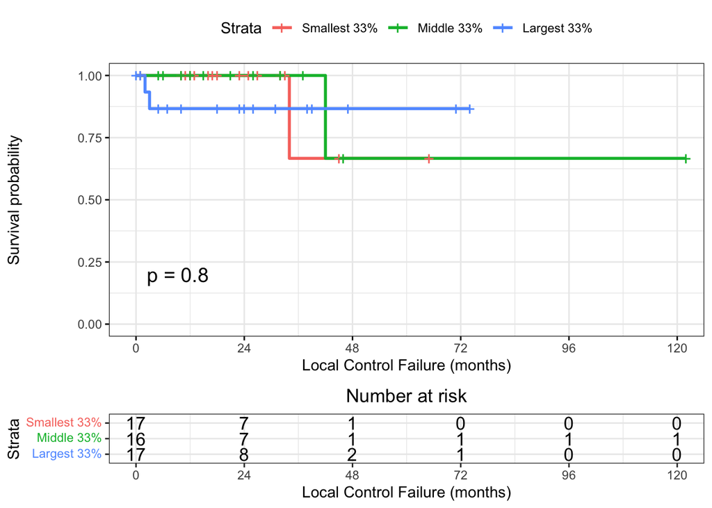

```r
## ## ## ## ## ## ## ## ## ## ## ## ## ## ## ## ## ## ## ## ## ## ## ## ##

## Three groups by tertiles by 33%

km_grp3_tert3 <- survfit(surv_lc ~ data_class_lc$pred_grp3_tert)

gg_grp3_tert <- ggsurvplot(km_grp3_tert3, data = data_class_lc, size = 1,
   conf.int = FALSE, # Add confidence interval
   pval = TRUE, # Add p-value
   risk.table = TRUE, # Add risk table
   risk.table.height = 0.25, # change if you have >2 groups
   risk.table.y.text.col = T, # show colors in table listing
   ncensor.plot = FALSE,
   ncensor.plot.height = 0.25,
   xlab = "Local Control Failure (months)", # adjust X axis label
   # xlim = c(0, 190),
   break.time.by = 24, # break X axis in time intervals
   # legend.labs = c("Lowest third Lin Pred.", "Middle third Lin Pred.",
   # "Top third Lin Pred."), # labels
   # title = "CisSig Score Tertile Cohorts (by 33%) - Yes Cisplatin",
   legend.labs = c("Smallest 33%", "Middle 33%", "Largest 33%"),
   # title = "LC - Preset Cutoffs (Tertiles)",
   ggtheme = theme_bw() + theme(plot.title = element_text(hjust = 0.5))
   )

gg_grp3_tert
```

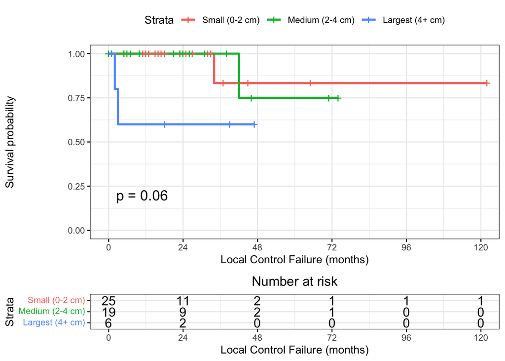

```r
## ## ## ## ## ## ## ## ## ## ## ## ## ## ## ## ## ## ## ## ## ## ## ## ##

## Three groups by manual cutoffs (0-2, 2-4, >4)

km_grp3_manual <- survfit(surv_lc ~ data_class_lc$pred_grp3_man)

gg_grp3_manual <- ggsurvplot(km_grp3_manual, data = data_class_lc, size = 1,
   conf.int = FALSE, # Add confidence interval
   pval = TRUE, # Add p-value
   risk.table = TRUE, # Add risk table
   risk.table.height = 0.25, # change if you have >2 groups
   risk.table.y.text.col = T, # show colors in table listing
   ncensor.plot = FALSE,
   ncensor.plot.height = 0.25,
   xlab = "Local Control Failure (months)", # adjust X axis label
   # xlim = c(0, 190),
   break.time.by = 24, # break X axis in time intervals
   # # legend.labs = c("Bottom 25% Lin Pred.", "Middle 25-75% Lin Pred.",
   # "Top 25% Lin Pred."), # labels
   # title = "CisSig Score Tertile Cohorts (by 25/50/25%) - Yes Cisplatin",
   legend.labs = c("Small (0-2 cm)", "Medium (2-4 cm)", "Largest (4+ cm)"),
   # title = "LC - Preset Cutoffs (0-2, 2-4, 4+)",
   ggtheme = theme_bw() + theme(plot.title = element_text(hjust = 0.5))
   )

gg_grp3_manual
```

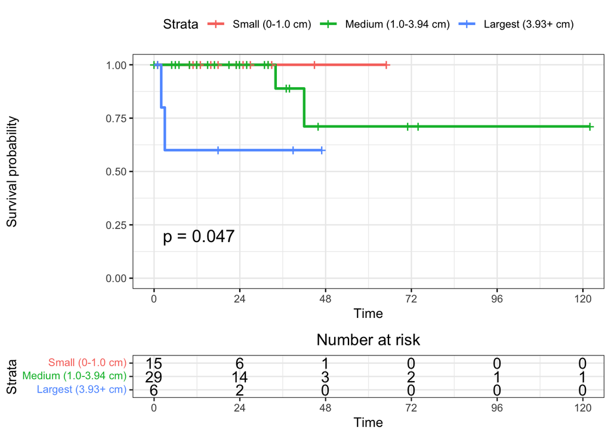

```r
## ## ## ## ## ## ## ## ## ## ## ## ## ## ## ## ## ## ## ## ## ## ## ## ##

## Optimal 3 group cutpoints

km_grp3_opt <- survfit(surv_lc ~ data_class_lc$pred_grp3_optimal)

gg_grp3_opt <- ggsurvplot(km_grp3_opt, data = data_class_lc, size = 1,
   conf.int = FALSE, # Add confidence interval
   pval = TRUE, # Add p-value
   risk.table = TRUE, # Add risk table
   risk.table.height = 0.25, # change if you have >2 groups
   risk.table.y.text.col = T, # show colors in table listing
   ncensor.plot = FALSE,
   ncensor.plot.height = 0.25,
   # xlab = "Local Control Failure (months)", # adjust X axis label
   # xlim = c(0, 190),
   break.time.by = 24, # break X axis in time intervals
   # legend.labs = c("Lowest third Lin Pred.", "Middle third Lin Pred.",
   # "Top third Lin Pred."), # labels
   # title = "CisSig Score Tertile Cohorts (optimal) - Yes Cisplatin",
   legend.labs = c("Small (0-1.0 cm)", "Medium (1.0-3.94 cm)", "Largest (3.93+ cm)"),
   # title = "LC - Optimal Cutoffs",
   ggtheme = theme_bw() + theme(plot.title = element_text(hjust = 0.5))
   )

gg_grp3_opt
```

```r
## ## ## ## ## ## ## ## ## ## ## ## ## ## ## ## ## ## ## ## ## ## ## ## ##
```

#### Plot together

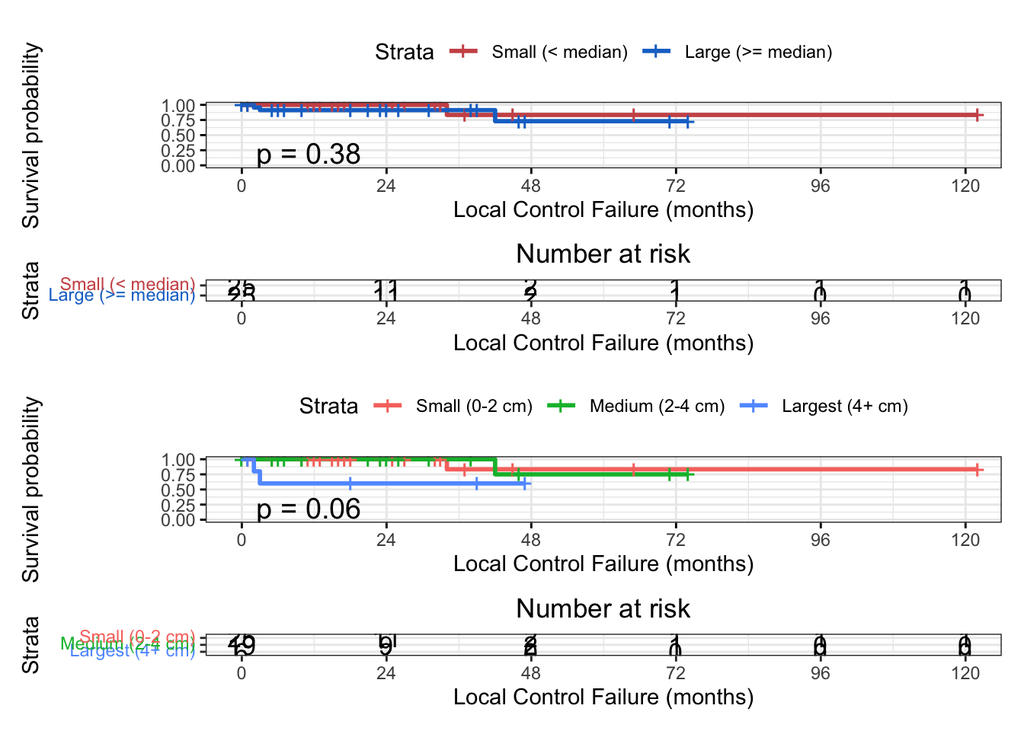

```r
combo_plot_preset <- gg_grp2_med$plot + gg_grp2_med$table +
   gg_grp3_manual$plot + gg_grp3_manual$table +
   plot_layout(nrow = 4, ncol = 1, heights = c(3, 1))

combo_plot_preset
```

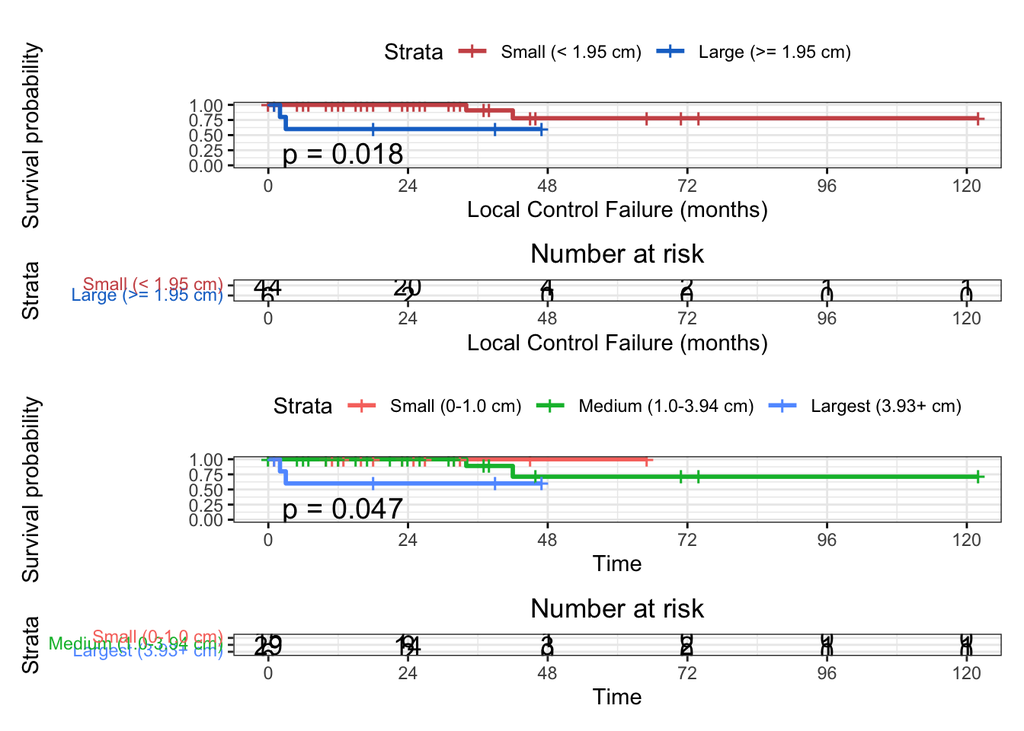

```r
ggsave(filename = here("results", "surv_lc_plots_preset.png"),
       plot = combo_plot_preset, height = 10, width = 7)


combo_plot_opt <- gg_grp2_opt$plot + gg_grp2_opt$table +
   gg_grp3_opt$plot + gg_grp3_opt$table +
   plot_layout(nrow = 4, ncol = 1, heights = c(3, 1))

combo_plot_opt
```

```r
ggsave(filename = here("results", "surv_lc_plots_opt.png"),
       plot = combo_plot_opt, height = 10, width = 7)
```

### Chemo-Free Time

We aren’t separating patients into cohorts for this analysis, but below, we’ll look at an intercept only survival model of chemotherapy free survival in all patients in this dataset.

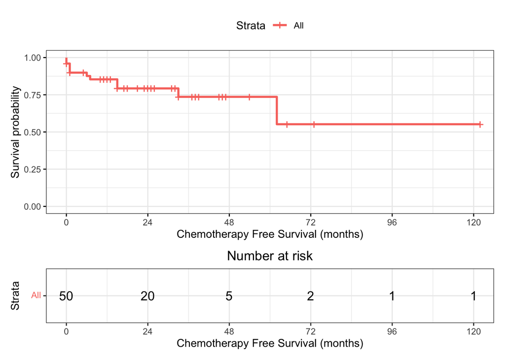

```r
## ## ## ## ## ## ## ## ## ## ## ## ## ## ## ## ## ## ## ## ## ## ## ## ##

## Intercept only

km_int <- survfit(surv_chemo ~ 1)

gg_int <- ggsurvplot(km_int, data = data_class_lc,
   conf.int = FALSE, # Add confidence interval
   risk.table = TRUE, # Add risk table
   xlab = "Chemotherapy Free Survival (months)", # adjust X axis label
   break.time.by = 24, # add tick every 12 months
   # title = "Chemotherapy Free Survival - Intercept only",
   ggtheme = theme_bw() + theme(plot.title = element_text(hjust = 0.5))
   )

combo_chemo_int <- gg_int$plot + gg_int$table +
   plot_layout(nrow = 2, ncol = 1, heights = c(3, 1))

combo_chemo_int
```

```r
ggsave(filename = here("results", "surv_chemo_int_only.png"),
       plot = combo_chemo_int, height = 5, width = 5)



## ## ## ## ## ## ## ## ## ## ## ## ## ## ## ## ## ## ## ## ## ## ## ## ##
```